# Table of Contents

# Ensemble Modelling

- [A Comprehensive Guide to Ensemble Learning](https://www.analyticsvidhya.com/blog/2018/06/comprehensive-guide-for-ensemble-models/?utm_source=blog&utm_medium=pycaret-machine-learning-model-seconds).

```
ensemble_model(estimator, method='Bagging', fold=10, n_estimators=10, round=4, verbose=True)

method: 'Bagging' or 'Boosting', default = 'Bagging'
```

```python
# pyc.ensemble_model?
```

```python
dt = pyc.create_model('dt')
```

|  | Accuracy | AUC | Recall | Prec. | F1 | Kappa |
| --- | --- | --- | --- | --- | --- | --- |
| 0 | 0.9993 | 0.8000 | 0.6000 | 1.0000 | 0.7500 | 0.7497 |
| 1 | 0.9991 | 0.9496 | 0.9000 | 0.6923 | 0.7826 | 0.7822 |
| 2 | 0.9987 | 0.9439 | 0.8889 | 0.5714 | 0.6957 | 0.6950 |
| 3 | 0.9987 | 0.7775 | 0.5556 | 0.6250 | 0.5882 | 0.5876 |
| 4 | 0.9991 | 0.8332 | 0.6667 | 0.7500 | 0.7059 | 0.7054 |
| 5 | 0.9989 | 0.8331 | 0.6667 | 0.6667 | 0.6667 | 0.6661 |
| 6 | 0.9987 | 0.7775 | 0.5556 | 0.6250 | 0.5882 | 0.5876 |
| 7 | 0.9996 | 0.9998 | 1.0000 | 0.8182 | 0.9000 | 0.8998 |
| 8 | 0.9996 | 0.9499 | 0.9000 | 0.9000 | 0.9000 | 0.8998 |
| 9 | 0.9995 | 0.9498 | 0.9000 | 0.8182 | 0.8571 | 0.8569 |
| Mean | 0.9991 | 0.8814 | 0.7633 | 0.7467 | 0.7434 | 0.7430 |
| SD | 0.0003 | 0.0805 | 0.1611 | 0.1295 | 0.1101 | 0.1103 |

## Bagging

```python
dt_bagged = pyc.ensemble_model(dt, n_estimators=50,method='Bagging')
```

|  | Accuracy | AUC | Recall | Prec. | F1 | Kappa |
| --- | --- | --- | --- | --- | --- | --- |
| 0 | 0.9993 | 0.8997 | 0.6000 | 1.0000 | 0.7500 | 0.7497 |
| 1 | 0.9995 | 0.9497 | 0.9000 | 0.8182 | 0.8571 | 0.8569 |
| 2 | 0.9995 | 0.9994 | 0.8889 | 0.8000 | 0.8421 | 0.8418 |
| 3 | 0.9987 | 0.8326 | 0.5556 | 0.6250 | 0.5882 | 0.5876 |
| 4 | 0.9995 | 0.8885 | 0.7778 | 0.8750 | 0.8235 | 0.8233 |
| 5 | 0.9996 | 0.8881 | 0.7778 | 1.0000 | 0.8750 | 0.8748 |
| 6 | 0.9989 | 0.9437 | 0.4444 | 0.8000 | 0.5714 | 0.5709 |
| 7 | 0.9998 | 1.0000 | 1.0000 | 0.9000 | 0.9474 | 0.9473 |
| 8 | 1.0000 | 1.0000 | 1.0000 | 1.0000 | 1.0000 | 1.0000 |
| 9 | 0.9996 | 0.9498 | 0.9000 | 0.9000 | 0.9000 | 0.8998 |
| Mean | 0.9994 | 0.9352 | 0.7844 | 0.8718 | 0.8155 | 0.8152 |
| SD | 0.0004 | 0.0540 | 0.1824 | 0.1118 | 0.1342 | 0.1344 |

```python
# dt_bagged_tuned = pyc.tune_model('dt', ensemble=True,
#      method='Bagging',fold=3, n_iter=10, optimize='Recall')
```

## Boosting

```python
# dt_boosted_tuned = pyc.tune_model('dt', ensemble=True, method='Boosting')
```

## Blending

```
blend_models(estimator_list='All', fold=10, round=4, method='hard', turbo=True, verbose=True)
```

```python
# pyc.blend_models?
```

```python
# blend_soft = pyc.blend_models(estimator_list = [dt, xgb,lda], method = 'soft')
```

```python
# blend_hard = pyc.blend_models(estimator_list = [dt, xgb,lda], method = 'hard')
```

## Stacking

Stacking is another popular technique for ensembling but is less commonly implemented due to practical difficulties. Stacking is an ensemble learning technique that combines multiple models via a meta-model. Another way to think about stacking is that multiple models are trained to predict the outcome and a meta-model is created that uses the predictions from those models as an input along with the original features.

Selecting which method and models to use in stacking depends on the statistical properties of the dataset. Experimenting with different models and methods is the best way to find out which configuration will work best. However as a general rule of thumb, the models with strong yet diverse performance tend to improve results when used in stacking. One way to measure diversity is the correlation of predictions between models. You can analyze this using the plot parameter.

```
stack_models(estimator_list, meta_model=None, fold=10, round=4, method='soft', restack=True, plot=False, finalize=False, verbose=True)
```

```python
# pyc.stack_models?
```

```python
# stack_soft = pyc.stack_models(estimator_list = [dt, xgb,lda], method = 'soft')

# stack_soft2 = pyc.stack_models(estimator_list = [xgb, lda],
#                                           method = 'soft',
#                                          meta_model=dt)
```

```python
# stack_hard = pyc.stack_models(estimator_list = [dt, xgb,lda], method = 'hard')
```

```python
# stack_soft_plot = pyc.stack_models([dt,xgb,lda], plot=True)
```

# Model Calibration

When performing classification you often not only want to predict the class label (outcome such as 0 or 1), but also obtain the probability of the respective outcome which provides a level of confidence on the prediction. Some models can give you poor estimates of the class probabilities and some do not even support probability prediction. Well calibrated classifiers are probabilistic and provide outputs in the form of probabilities that can be directly interpreted as a confidence level. PyCaret allows you to calibrate the probabilities of a given model through the calibrate_model() function.

```
calibrate_model(estimator, method='sigmoid', fold=10, round=4, verbose=True)

method : string, default = 'sigmoid'
The method to use for calibration. Can be 'sigmoid' which corresponds to Platt's
method or 'isotonic' which is a non-parametric approach. It is not advised to use
isotonic calibration with too few calibration samples
```

```python
# pyc.calibrate_model?
```

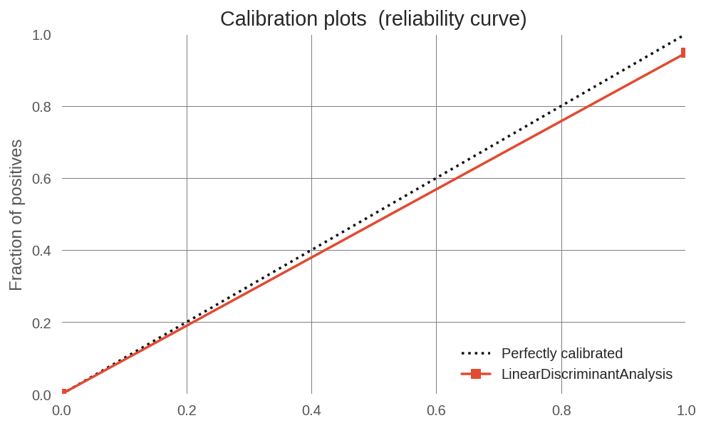

```python
pyc.plot_model(lda, plot='calibration')
```

```python
lda_tuned_calibrated = pyc.calibrate_model(lda,fold=5,
                                            method='sigmoid')
```

|  | Accuracy | AUC | Recall | Prec. | F1 | Kappa |
| --- | --- | --- | --- | --- | --- | --- |
| 0 | 0.9992 | 0.9839 | 0.5789 | 0.9167 | 0.7097 | 0.7093 |
| 1 | 0.9989 | 0.9868 | 0.4211 | 0.8889 | 0.5714 | 0.5709 |
| 2 | 0.9992 | 0.9697 | 0.6111 | 0.8462 | 0.7097 | 0.7093 |
| 3 | 0.9991 | 0.9731 | 0.5263 | 0.9091 | 0.6667 | 0.6662 |
| 4 | 0.9994 | 0.9991 | 0.6316 | 1.0000 | 0.7742 | 0.7739 |
| Mean | 0.9991 | 0.9825 | 0.5538 | 0.9122 | 0.6863 | 0.6859 |
| SD | 0.0001 | 0.0105 | 0.0753 | 0.0503 | 0.0669 | 0.0670 |

```python
mean_row = 'Mean	0.9991	0.9825	0.5538	0.9122	0.6863	0.6859'
df_eval = compare_new_models('lda_tuned_calibrated','fold=5',mean_row,df_eval=df_eval,sort='Recall')
```

|  | Model | Description | Accuracy | AUC | Recall | Precision | F1 | Kappa |
| --- | --- | --- | --- | --- | --- | --- | --- | --- |
| 0 | cb_tuned | fold=5 | 0.9996 | 0.9659 | 0.7865 | 0.9667 | 0.8642 | 0.8639 |
| 1 | lda_tuned | fold=5 | 0.9995 | 0.9833 | 0.7760 | 0.9217 | 0.8423 | 0.8420 |
| 2 | xgb | default | 0.9994 | 0.9585 | 0.7345 | 0.9102 | 0.8047 | 0.8044 |
| 3 | cb | default | 0.9995 | 0.9554 | 0.7345 | 0.9548 | 0.8215 | 0.8212 |
| 4 | lda | default | 0.9992 | 0.9677 | 0.7255 | 0.8340 | 0.7661 | 0.7657 |
| 5 | xgb_tuned | tuned | 0.9992 | 0.9677 | 0.7255 | 0.8340 | 0.7661 | 0.7657 |
| 6 | lda_tuned | n_iter=100,fold=10 | 0.9992 | 0.9677 | 0.7255 | 0.8340 | 0.7661 | 0.7657 |
| 7 | lda_tuned_calibrated | fold=5 | 0.9991 | 0.9825 | 0.5538 | 0.9122 | 0.6863 | 0.6859 |

```python
lda_tuned_calibrated_iso = pyc.calibrate_model(lda_tuned,
                            fold=5, method='isotonic')
```

|  | Accuracy | AUC | Recall | Prec. | F1 | Kappa |
| --- | --- | --- | --- | --- | --- | --- |
| 0 | 0.9995 | 0.9764 | 0.7895 | 0.9375 | 0.8571 | 0.8569 |
| 1 | 0.9991 | 0.9920 | 0.7368 | 0.7368 | 0.7368 | 0.7364 |
| 2 | 0.9995 | 0.9616 | 0.7778 | 0.8750 | 0.8235 | 0.8233 |
| 3 | 0.9995 | 0.9645 | 0.7895 | 0.9375 | 0.8571 | 0.8569 |
| 4 | 0.9999 | 0.9995 | 0.9474 | 1.0000 | 0.9730 | 0.9729 |
| Mean | 0.9995 | 0.9788 | 0.8082 | 0.8974 | 0.8495 | 0.8493 |
| SD | 0.0003 | 0.0149 | 0.0722 | 0.0895 | 0.0758 | 0.0759 |

```python
mean_row = 'Mean	0.9995	0.9788	0.8082	0.8974	0.8495	0.8493'
df_eval = compare_new_models('lda_tuned_calibrated_iso','fold=5',
                             mean_row,df_eval=df_eval,sort='Recall')
```

|  | Model | Description | Accuracy | AUC | Recall | Precision | F1 | Kappa |
| --- | --- | --- | --- | --- | --- | --- | --- | --- |
| 0 | lda_tuned_calibrated_iso | fold=5 | 0.9995 | 0.9788 | 0.8082 | 0.8974 | 0.8495 | 0.8493 |
| 1 | cb_tuned | fold=5 | 0.9996 | 0.9659 | 0.7865 | 0.9667 | 0.8642 | 0.8639 |
| 2 | lda_tuned | fold=5 | 0.9995 | 0.9833 | 0.7760 | 0.9217 | 0.8423 | 0.8420 |
| 3 | xgb | default | 0.9994 | 0.9585 | 0.7345 | 0.9102 | 0.8047 | 0.8044 |
| 4 | cb | default | 0.9995 | 0.9554 | 0.7345 | 0.9548 | 0.8215 | 0.8212 |
| 5 | lda | default | 0.9992 | 0.9677 | 0.7255 | 0.8340 | 0.7661 | 0.7657 |
| 6 | xgb_tuned | tuned | 0.9992 | 0.9677 | 0.7255 | 0.8340 | 0.7661 | 0.7657 |
| 7 | lda_tuned | n_iter=100,fold=10 | 0.9992 | 0.9677 | 0.7255 | 0.8340 | 0.7661 | 0.7657 |
| 8 | lda_tuned_calibrated | fold=5 | 0.9991 | 0.9825 | 0.5538 | 0.9122 | 0.6863 | 0.6859 |

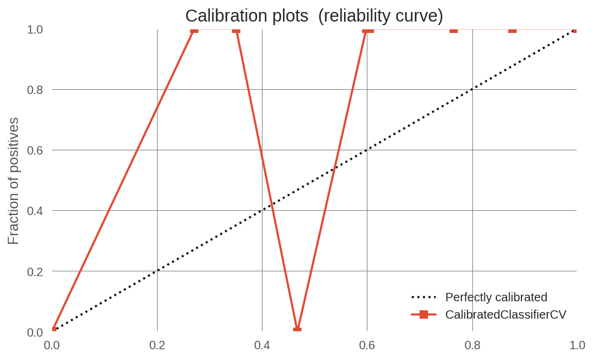

```python
pyc.plot_model(lda_tuned_calibrated, plot='calibration')
```

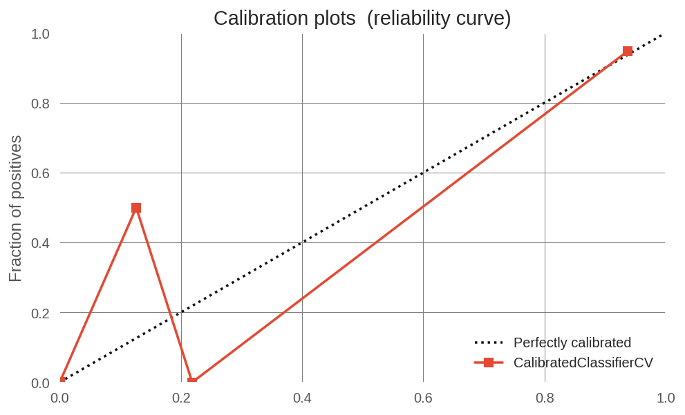

```python
pyc.plot_model(lda_tuned_calibrated_iso, plot='calibration')
```

# Model Interpretation

```
interpret_model(estimator, plot='summary', feature=None, observation=None)
```

```python
# pyc.interpret_model?
```

```python
df_eval
```

|  | Model | Description | Accuracy | AUC | Recall | Precision | F1 | Kappa |
| --- | --- | --- | --- | --- | --- | --- | --- | --- |
| 0 | lda_tuned_calibrated_iso | fold=5 | 0.9995 | 0.9788 | 0.8082 | 0.8974 | 0.8495 | 0.8493 |
| 1 | cb_tuned | fold=5 | 0.9996 | 0.9659 | 0.7865 | 0.9667 | 0.8642 | 0.8639 |
| 2 | lda_tuned | fold=5 | 0.9995 | 0.9833 | 0.7760 | 0.9217 | 0.8423 | 0.8420 |
| 3 | xgb | default | 0.9994 | 0.9585 | 0.7345 | 0.9102 | 0.8047 | 0.8044 |
| 4 | cb | default | 0.9995 | 0.9554 | 0.7345 | 0.9548 | 0.8215 | 0.8212 |
| 5 | lda | default | 0.9992 | 0.9677 | 0.7255 | 0.8340 | 0.7661 | 0.7657 |
| 6 | xgb_tuned | tuned | 0.9992 | 0.9677 | 0.7255 | 0.8340 | 0.7661 | 0.7657 |
| 7 | lda_tuned | n_iter=100,fold=10 | 0.9992 | 0.9677 | 0.7255 | 0.8340 | 0.7661 | 0.7657 |
| 8 | lda_tuned_calibrated | fold=5 | 0.9991 | 0.9825 | 0.5538 | 0.9122 | 0.6863 | 0.6859 |

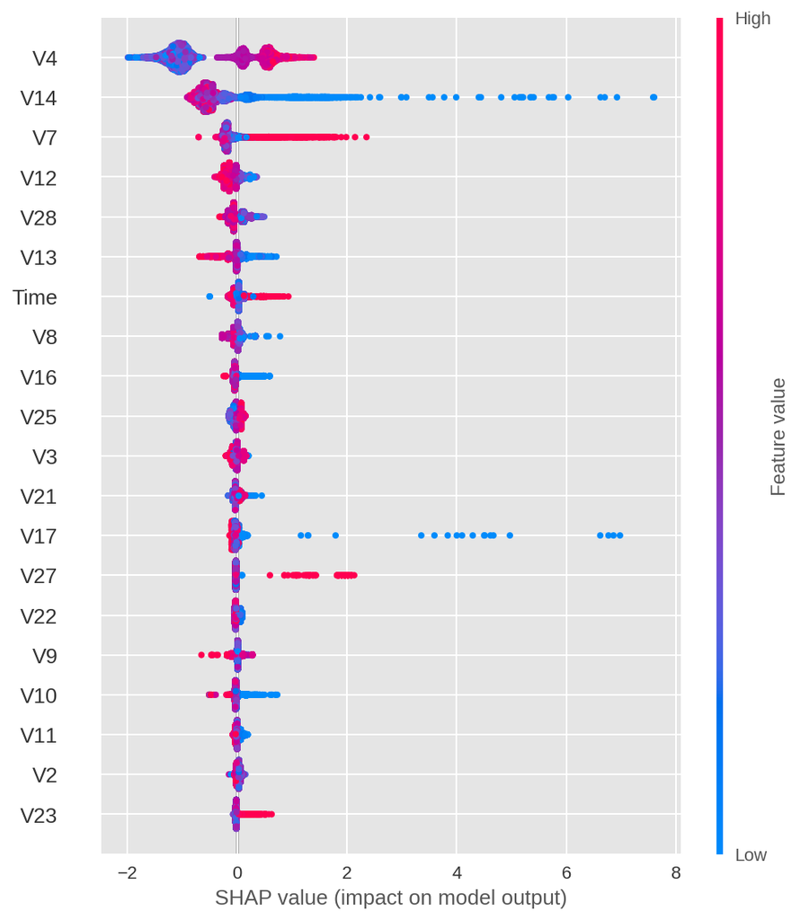

```python
# interpret_model: SHAP
pyc.interpret_model(xgb)
```

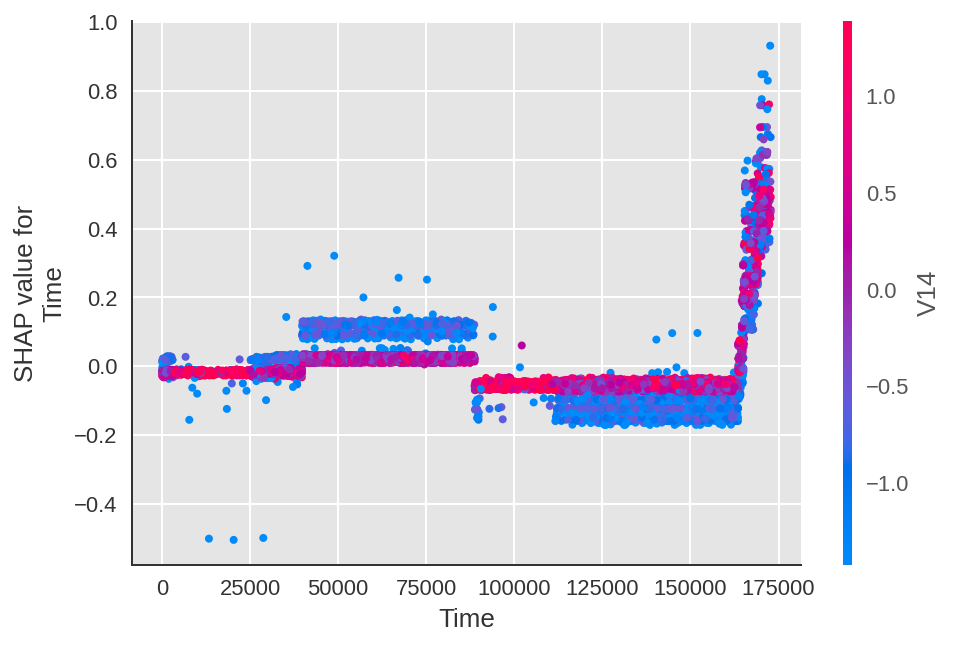

```python
# interpret model : Correlation
pyc.interpret_model(xgb,plot='correlation')
```

# Model Predictions

```
predict_model(estimator, data=None, probability_threshold=None,
platform=None, authentication=None)
```

```python
# pyc.predict_model?
```

```python
df_test.iloc[:5,-5:]
```

|  | V26 | V27 | V28 | Amount | Class |
| --- | --- | --- | --- | --- | --- |
| 248750 | -0.775158 | 0.261012 | 0.058359 | 18.70 | 0 |
| 161573 | -0.235203 | -0.036910 | -0.227111 | 9.99 | 0 |
| 65893 | 0.011709 | 0.029830 | -0.080522 | 112.00 | 0 |
| 12836 | 0.974426 | -0.067625 | 0.007633 | 23.27 | 0 |
| 132224 | -0.252303 | 0.009928 | 0.015153 | 74.97 | 0 |

```python
df_preds = pyc.predict_model(lda_tuned_calibrated,df_test)
df_preds.iloc[:5,-5:]
```

|  | V28 | Amount | Class | Label | Score |
| --- | --- | --- | --- | --- | --- |
| 0 | 0.058359 | 18.70 | 0 | 0 | 0.0008 |
| 1 | -0.227111 | 9.99 | 0 | 0 | 0.0006 |
| 2 | -0.080522 | 112.00 | 0 | 0 | 0.0006 |
| 3 | 0.007633 | 23.27 | 0 | 0 | 0.0006 |
| 4 | 0.015153 | 74.97 | 0 | 0 | 0.0006 |